# Principle Component Analysis

## Data

The data you will be using comes from the Assistments online intelligent tutoring system (https://www.assistments.org/). It describes students working through online math problems. Each student has the following data associated with them:

- id
- prior_prob_count: How many problems a student has answered in the system prior to this session
- prior_percent_correct: The percentage of problems a student has answered correctly prior to this session
- problems_attempted: The number of problems the student has attempted in the current session
- mean_correct: The average number of correct answers a student made on their first attempt at problems in the current session
- mean_hint: The average number of hints a student asked for in the current session
- mean_attempt: The average number of attempts a student took to answer a problem in the current session
- mean_confidence: The average confidence each student has in their ability to answer the problems in the current session

## Start by uploading the data

```r
D1 <- read.csv("Assistments-confidence.csv")

  #We won't need the id variable, so remove that.
D1$id <- NULL
```

## Create a correlation matrix of the relationships between the variables, including correlation coefficients for each pair of variables/features.

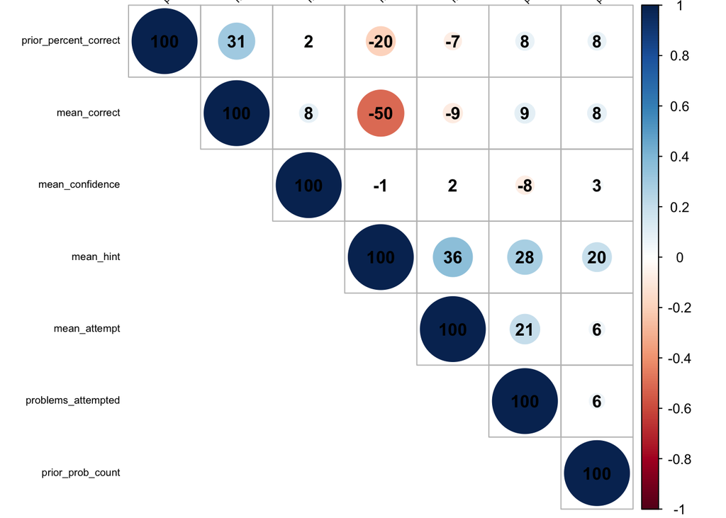

```r
#You can install the corrplot package to plot some pretty correlation matrices (sometimes called correlograms)

library(corrplot)
#Generate pairwise correlations
COR <- cor(D1)

corrplot(COR, order="AOE", method="circle", tl.pos="lt", type="upper",
tl.col="black", tl.cex=0.6, tl.srt=45,
        addCoef.col="black", addCoefasPercent = TRUE,
        sig.level=0.50, insig = "blank")
```

```r
#Study your correlogram image and save it, you will need it later
```

## Create a new data frame with the mean_correct variables removed

```r
D2<-D1
D2$mean_correct<-NULL

#The, scale and center your data for easier interpretation
D2 <- scale(D2, center = TRUE)
```

## Now run the PCA on the new data frame

```r
pca <- prcomp(D2, scale = TRUE)
```

## Although princomp does not generate the eigenvalues directly for us, we can print a list of the standard deviation of the variance accounted for by each component.

```r
pca$sdev
```

```
## [1] 1.2825140 1.0543565 1.0245688 0.9621486 0.8556715 0.7320146
```

```r
#To convert this into variance accounted for we can square it, these numbers are proportional to the eigenvalue

pca$sdev^2
```

```
## [1] 1.6448423 1.1116675 1.0497412 0.9257299 0.7321737 0.5358454
```

```r
#A summary of our pca will give us the proportion of variance accounted for by each component

summary(pca)
```

```
## Importance of components:
##                           PC1    PC2    PC3    PC4    PC5     PC6
## Standard deviation     1.2825 1.0544 1.0246 0.9621 0.8557 0.73201
## Proportion of Variance 0.2741 0.1853 0.1750 0.1543 0.1220 0.08931
## Cumulative Proportion  0.2741 0.4594 0.6344 0.7887 0.9107 1.00000
```

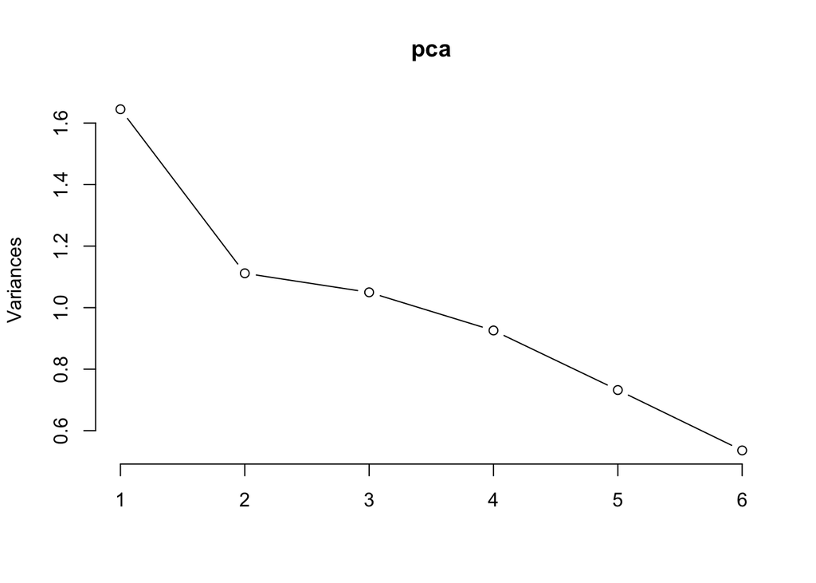

```r
#We can look at this to get an idea of which components we should keep and which we should drop

plot(pca, type = "lines")
```

## Think about which components you would drop and make a decision

## Part II

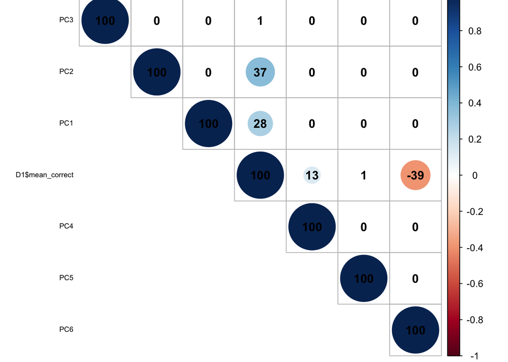

```r
#Now, create a data frame of the transformed data from your pca.

D3 <- as.data.frame(pca$x)

#Attach the variable "mean_correct" from your original data frame to D3.

D4 <- cbind(D3, as.data.frame(D1$mean_correct))

#Now re-run your scatterplots and correlations between the transformed data and mean_correct. If you had dropped some components would you have lost important infomation about mean_correct?

COR2 <- cor(D4)

corrplot(COR2, order="AOE", method="circle", tl.pos="lt", type="upper",
tl.col="black", tl.cex=0.6, tl.srt=45,
        addCoef.col="black", addCoefasPercent = TRUE,
        sig.level=0.50, insig = "blank")
```

## Now print out the eigenvectors (often called loadings) for the components you generated:

```r
pca$rotation
```

```
##                               PC1         PC2         PC3        PC4
## prior_prob_count      -0.26034140  0.45818753 -0.40090679 -0.6897642
## prior_percent_correct  0.16840319  0.81617867  0.09267306  0.2640040
## problems_attempted    -0.45568733  0.31685183  0.36387724  0.3168141
## mean_hint             -0.63337594 -0.12501620 -0.08008842 -0.1122586
## mean_attempt          -0.54200011 -0.08510858 -0.04585364  0.3108682
## mean_confidence        0.03581325  0.02547483 -0.83051917  0.4948890
##                                PC5         PC6
## prior_prob_count      -0.007142834 -0.29280482
## prior_percent_correct  0.298843852  0.37134715
## problems_attempted    -0.592336569 -0.32911025
## mean_hint             -0.102302115  0.74412634
## mean_attempt           0.697232132 -0.33781385
## mean_confidence       -0.251357022 -0.01452143
```

```r
#Examine the eigenvectors, notice that they are a little difficult to interpret. It is much easier to make sense of them if we make them proportional within each component

loadings <- abs(pca$rotation) #abs() will make all eigenvectors positive

sweep(loadings, 2, colSums(loadings), "/") #sweep() computes each row as a proportion of the column. (There must be a way to do this with dplyr()?)
```

```
##                              PC1        PC2        PC3        PC4
## prior_prob_count      0.12423113 0.25081186 0.22101700 0.31516257
## prior_percent_correct 0.08035956 0.44677621 0.05108998 0.12062699
## problems_attempted    0.21744737 0.17344469 0.20060288 0.14475664
## mean_hint             0.30223780 0.06843387 0.04415217 0.05129246
## mean_attempt          0.25863458 0.04658844 0.02527878 0.14203987
## mean_confidence       0.01708956 0.01394492 0.45785919 0.22612148
##                               PC5        PC6
## prior_prob_count      0.003664468 0.14011651
## prior_percent_correct 0.153315014 0.17770154
## problems_attempted    0.303884750 0.15748983
## mean_hint             0.052483764 0.35608836
## mean_attempt          0.357699023 0.16165478
## mean_confidence       0.128952980 0.00694897
```

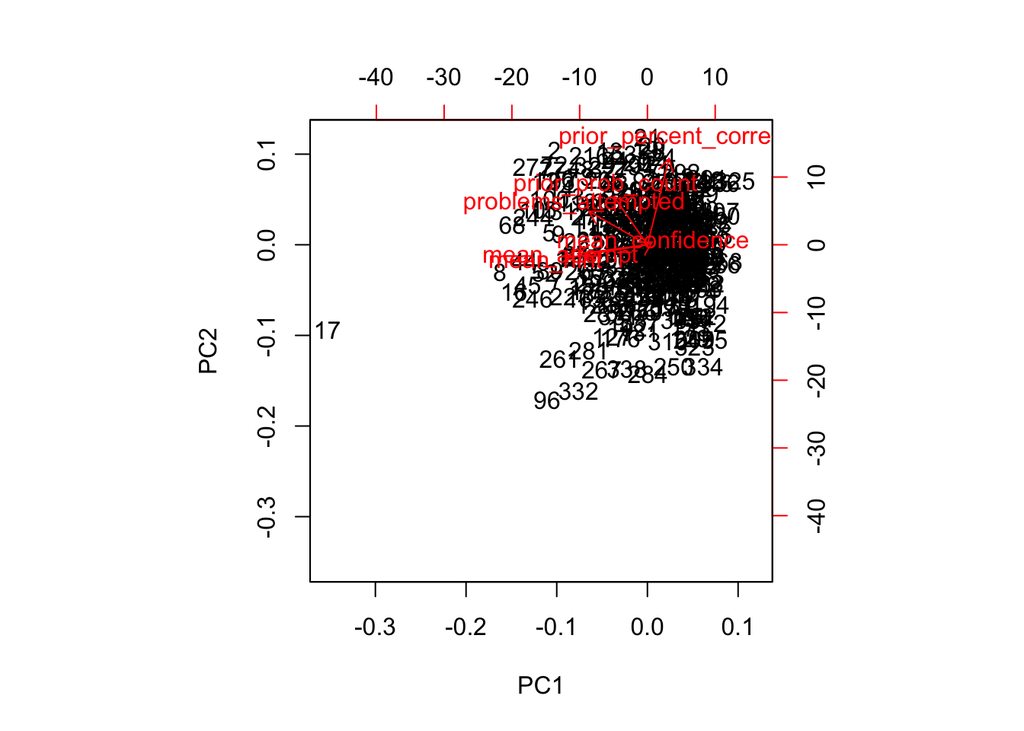

```r
#Now examine your components and try to come up with substantive descriptions of what some might represent?

#You can generate a biplot to help you, though these can be a bit confusing. They plot the transformed data by the first two components. Therefore, the axes represent the direction of maximum variance. Then mapped onto this point cloud are the original directions of the variables, depicted as red arrows. It is supposed to provide a visualization of which variables "go together". Variables that possibly represent the same underlying construct point in the same direction.

biplot(pca)
```

```r
#Calculate values for each student that represent these your composite variables and then create a new correlogram showing their relationship to mean_correct.
```

### Now examine your components and try to come up with substantive descriptions of what some might represent?

PC1 looks like the use of Assistments (mean_hint and mean_attempt), as well as general problems attempted in the current session.

PC2 looks like the student’s prior experience (prior_prob_count and prior_percent_correct), as well as problems attempted in the current session

PC3 looks like it can be defined as the student’s confidence level in the current system, as 45.7% is derived from that variable. As before, the number of problems attempted will have an influence (understandably), as well as prior_prob_count.

One could make an argument that PC4 could be included (as it explains a percentage of the variance that is close to that of PC3). It can be defined as the total number of problems answered, as well as a confidence in the new system.

# Part III

## Also in this repository is a data set and codebook from Rod Martin, Patricia Puhlik-Doris, Gwen Larsen, Jeanette Gray, Kelly Weir at the University of Western Ontario about people’s sense of humor. Can you perform a PCA on this data?

Thirty two questions were posed in this survey. The research established four “scale scores” for these questions: affiliative, self-enhancing, agressive(sic) and self-defeating. I ran a PCA on these scale scores, and included age and gender.

PC2 (18.7% of the variance) appears to be demographic-based (age and gender) and how people interact with others (affiliative and agressive)

PC3 (15.95%) is focused on gender and the four scale scores, with emphasis on ways of fitting in (affiliative and self-defeating), whereas PC4 (15.59%) focuses on age (with less focus on gender than in PC2) and the way that people interact with others.

```r
library(dplyr)
D3 <- read.csv("humor_data.csv")
D4 <- select(D3, affiliative, selfenhancing, agressive, selfdefeating, age, gender)
D5 <- scale(D4, center = TRUE)
pcahumor <- prcomp(D5, scale = TRUE)
pcahumor$sdev
```

```
## [1] 1.2864484 1.0594444 0.9781177 0.9670713 0.8598220 0.7690209
```

```r
pcahumor$sdev^2
```

```
## [1] 1.6549496 1.1224223 0.9567142 0.9352269 0.7392939 0.5913931
```

```r
summary(pcahumor)
```

```
## Importance of components:
##                           PC1    PC2    PC3    PC4    PC5     PC6
## Standard deviation     1.2864 1.0594 0.9781 0.9671 0.8598 0.76902
## Proportion of Variance 0.2758 0.1871 0.1595 0.1559 0.1232 0.09857
## Cumulative Proportion  0.2758 0.4629 0.6223 0.7782 0.9014 1.00000
```

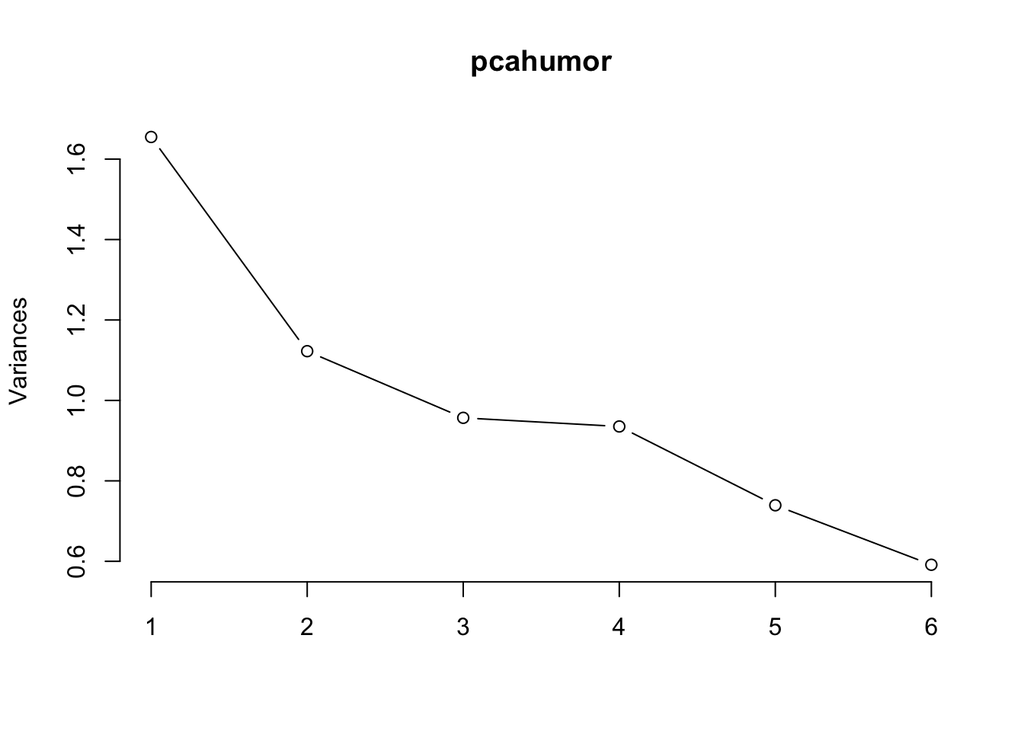

```r
plot(pcahumor, type = "lines")
```

```r
pcahumor$rotation
```

```
##                        PC1         PC2        PC3          PC4        PC5
## affiliative    0.503982164 -0.22401257  0.4149668  0.362996362  0.1561161
## selfenhancing  0.592587954 -0.02026991  0.3013298  0.007874646  0.1077573
## agressive      0.383300061  0.38708608 -0.3392093 -0.512791992  0.5222243
## selfdefeating  0.492209652  0.04557244 -0.4273169 -0.028195904 -0.7484693
## age           -0.004880476 -0.61084036  0.2469646 -0.733931278 -0.1412640
## gender        -0.075022650  0.65143616  0.6151005 -0.256448580 -0.3333707
##                       PC6
## affiliative    0.60620487
## selfenhancing -0.73888791
## agressive      0.22914756
## selfdefeating  0.10978031
## age            0.08513562
## gender         0.12145749
```

```r
loadings <- abs(pcahumor$rotation)
sweep(loadings, 2, colSums(loadings), "/")
```

```
##                       PC1        PC2       PC3         PC4        PC5
## affiliative   0.245607383 0.11551699 0.1769666 0.190825867 0.07770056
## selfenhancing 0.288787951 0.01045262 0.1285050 0.004139673 0.05363191
## agressive     0.186794953 0.19960942 0.1446591 0.269572886 0.25991630
## selfdefeating 0.239870244 0.02350043 0.1822334 0.014822484 0.37252073
## age           0.002378419 0.31499321 0.1053204 0.385825004 0.07030853
## gender        0.036561049 0.33592733 0.2623155 0.134814086 0.16592198
##                      PC6
## affiliative   0.32063919
## selfenhancing 0.39081907
## agressive     0.12120273
## selfdefeating 0.05806596
## age           0.04503068
## gender        0.06424236
```

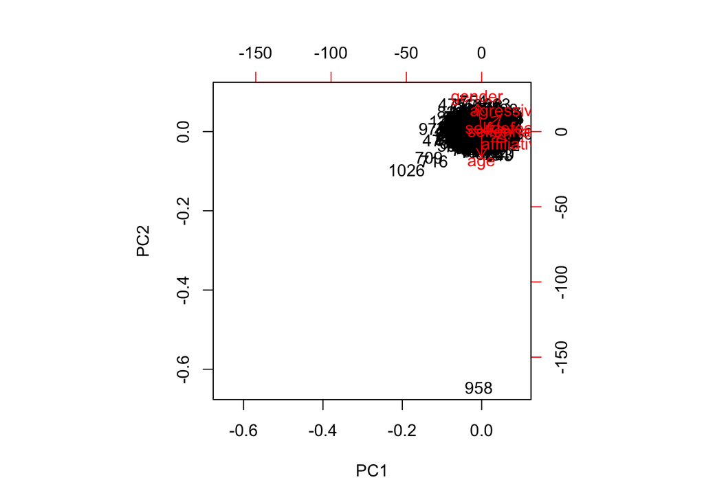

```r
biplot(pcahumor)
```